# Building and Zoning Permits In Philadelphia

Zhenzhao Xu - 2021/9/26

```python
import pandas as pd
import matplotlib.pyplot as plt
import seaborn as sns
import geopandas as gpd
import altair as alt
```

**Three datasets are used in this assignment:**

1. Licenses and Inspections Building and Zoning Permits (2016-now)

   https://www.opendataphilly.org/dataset/licenses-and-inspections-building-permits
1. Residential property assessment data from Lecture 3B (2019)

   https://www.opendataphilly.org/dataset/opa-property-assessments
2. Zillow neighborhood data from Lecture 3B.

```python
permits = pd.read_csv("./data/permits2016-now.csv")
# or
# permits = pd.read_csv("https://phl.carto.com/api/v2/sql?filename=permits&format=csv&skipfields=cartodb_id,the_geom,the_geom_webmercator&q=SELECT%20*,%20ST_Y(the_geom)%20AS%20lat,%20ST_X(the_geom)%20AS%20lng%20FROM%20permits%20WHERE%20permitissuedate%20%3E=%20%272016-01-01%27")
```

```python
permits.head()
```

|  | objectid | permitnumber | addressobjectid | parcel_id_num | permittype | permitdescription | commercialorresidential | typeofwork | approvedscopeofwork | permitissuedate | ... | unit_num | zip | censustract | council_district | opa_owner | systemofrecord | geocode_x | geocode_y | lat | lng |
| --- | --- | --- | --- | --- | --- | --- | --- | --- | --- | --- | --- | --- | --- | --- | --- | --- | --- | --- | --- | --- | --- |
| 0 | 29 | 1005844 | 461205.0 | 592432 | ZP_USE | USE PERMIT | NaN | ENTSTR | FOR THE ESTABLISHMENT OF A UNITY OF USE TO CRE... | 2019-08-29 10:56:10 | ... | NaN | 19145-4112 | 38.0 | 2.0 | CEDAR-SOUTH PHILADELPHIA | HANSEN | 2.687554e+06 | 224208.641261 | 39.920151 | -75.186071 |
| 1 | 30 | 1005882 | 769294.0 | 199999 | BP_SIGN | SIGN PERMIT | NaN | SIGNAC | FOR THE INSTALLATION OF A PROJECTING BLADE SIG... | 2019-09-20 11:27:58 | ... | A | 19107-3110 | 5.0 | 1.0 | PR 907 MARKET LP | HANSEN | 2.695632e+06 | 236039.978396 | 39.951968 | -75.156049 |
| 2 | 31 | 1006099 | 540971.0 | 251893 | EP_ELECTRL | ELECTRICAL PERMIT | NaN | EZELEC | REPLACE TWO GANG METER SOCKET WITH THREE GANG ... | 2019-09-09 13:59:55 | ... | NaN | 19152-2723 | 336.0 | 10.0 | IG MANAGEMENT LLC | HANSEN | 2.723084e+06 | 277667.374933 | 40.063932 | -75.053643 |
| 3 | 32 | 1006108 | 134162275.0 | 64223 | RESIDENTIAL BUILDING | RESIDENTIAL BUILDING PERMIT | RESIDENTIAL | ADDITION AND/OR ALTERATION | INTERIOR ALTERATIONS TO EXISTING 2 STORY SINGL... | 2019-09-30 08:20:00 | ... | NaN | 19121-2726 | 149.0 | 5.0 | SCHROTH ELIZABETH, PERHOSKY JOSEPH | ECLIPSE | 2.687864e+06 | 246485.318823 | 39.981252 | -75.182661 |
| 4 | 33 | 1006582 | 280129.0 | 36531 | PP_PLUMBNG | PLUMBING PERMIT | NaN | EZPLUM | REPLACE WATER & WASTE LINE 2-WATER CLOSET, 2-L... | 2019-09-03 14:20:46 | ... | NaN | 19118-2822 | 387.0 | 8.0 | MAY KATHLEEN | HANSEN | 2.680349e+06 | 281693.537845 | 40.078460 | -75.205845 |

5 rows × 32 columns

## 1. The change of total building and zoning permits number

```python
permits.permitissuedate = pd.to_datetime(permits.permitissuedate)
permits["year"] = permits.permitissuedate.dt.strftime("%Y").astype("int")
permits["month"] = permits.permitissuedate.dt.strftime("%m").astype("int")
permits["month_text"] = permits.permitissuedate.dt.strftime("%b")
```

```python
permitsByYear = (permits
                 .groupby(["month","month_text","year"], as_index=0)
                 .agg({"permitnumber":"count"}))
permitsByYear.head()
```

|  | month | month_text | year | permitnumber |
| --- | --- | --- | --- | --- |
| 0 | 1 | Jan | 2016 | 3739 |
| 1 | 1 | Jan | 2017 | 4273 |
| 2 | 1 | Jan | 2018 | 4203 |
| 3 | 1 | Jan | 2019 | 5128 |
| 4 | 1 | Jan | 2020 | 5305 |

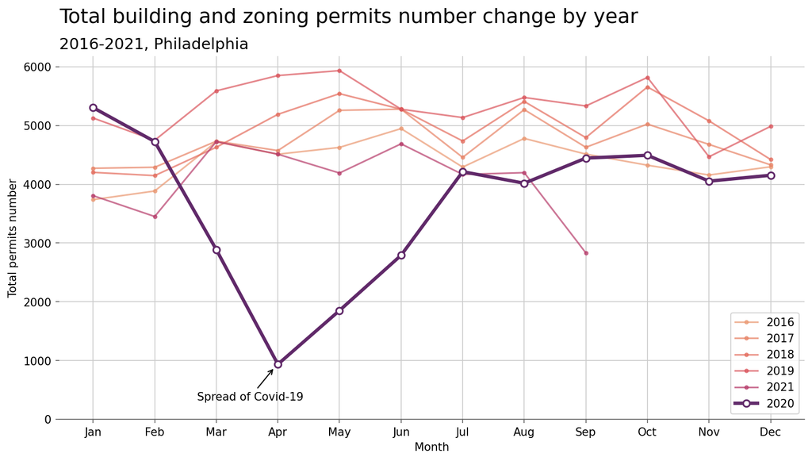

```python
plt.figure(figsize=(12,6),dpi=150)

pal = sns.color_palette("flare", n_colors=10,).as_hex()
pal_year = dict(zip(permitsByYear.year.unique(),pal))

for year,data in permitsByYear.groupby("year"):
    if year == 2020: continue
    plt.plot("month_text", "permitnumber", data = data,
             color=pal_year[year], marker=".",
             alpha=.7, label=year)

plt.plot("month_text", "permitnumber", data = permitsByYear[permitsByYear.year==2020],
         color=pal[-1], marker="o",mfc="#ffffff",mew=1.5,
         label=2020,lw=3)

plt.suptitle("Total building and zoning permits number change by year",
             size=18,x=0.125,horizontalalignment="left")
plt.title("2016-2021, Philadelphia", size=14,loc='left')
plt.xlabel("Month")
plt.ylim(bottom=0)
plt.ylabel("Total permits number")
plt.grid(axis="both",c="#cccccc")
plt.tick_params(color='#666666')
plt.gca().spines['bottom'].set
plt.gca().spines['bottom'].set_edgecolor('#666666')
plt.gca().spines['top'].set_visible(False)
plt.gca().spines['right'].set_visible(False)
plt.gca().spines['left'].set_visible(False)
plt.legend(loc="lower right")
plt.annotate("Spread of Covid-19",(2.95,890),xytext=(-70, -30),
             textcoords='offset points', arrowprops=dict(arrowstyle="->"))
plt.show()
```

**Discussion:**

1. Number of building permits in 2020 received a big setback because of Covid-19.
2. Before 2020, the number of building permits gradually increases every year.

**Reason for choosing matplotlib:**

The structure of data to visualize is pretty simple, and line plot is relatively simple.

## 2. Commercial and residential permit number of each zipcode

Filtering data

```python
permits_CnR = permits[~permits["commercialorresidential"].isna()].copy()
permits_CnR = permits_CnR[permits_CnR["zip"].between("19019","19160")]
permits_CnR = permits_CnR[["commercialorresidential","zip"]]
permits_CnR['zip'] = permits_CnR.zip.str.split("-",expand=True)[[0]]
```

```python
permits_CnR = (
    permits_CnR
    .groupby(["zip","commercialorresidential"])
    .agg({"commercialorresidential":"count"})
    .rename({"commercialorresidential":"totalNumber"},axis=1)
    .reset_index()
    .rename({"commercialorresidential":"type"},axis=1)
    .pivot(index='zip', columns='type', values='totalNumber')
    .reset_index().fillna(0)
)
permits_CnR["totalNumber"] = permits_CnR["COMMERCIAL"]+permits_CnR["RESIDENTIAL"]
permits_CnR = permits_CnR.sort_values("totalNumber",ascending=False).reset_index(drop=True)
permits_CnR.head()
```

| type | zip | COMMERCIAL | RESIDENTIAL | totalNumber |
| --- | --- | --- | --- | --- |
| 0 | 19146 | 2348.0 | 6120.0 | 8468.0 |
| 1 | 19121 | 2232.0 | 3875.0 | 6107.0 |
| 2 | 19125 | 1853.0 | 3970.0 | 5823.0 |
| 3 | 19104 | 4098.0 | 1691.0 | 5789.0 |
| 4 | 19122 | 2266.0 | 2962.0 | 5228.0 |

Plotting data

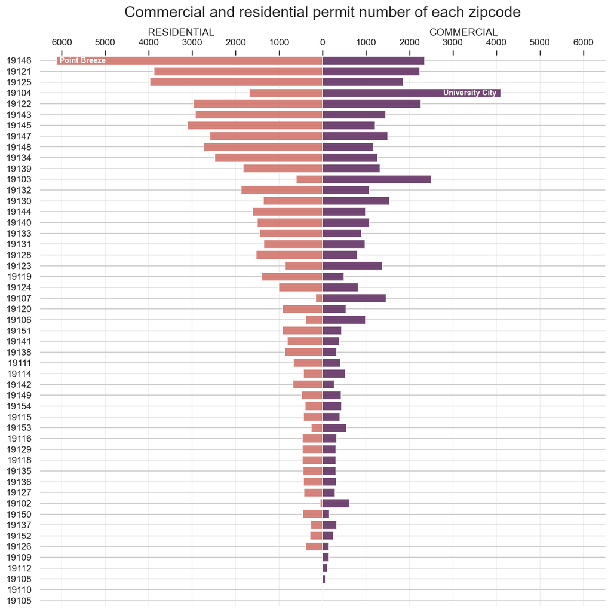

```python
sns.set_theme(style="whitegrid")
f, ax = plt.subplots(figsize=(12,12),dpi=150, ncols=2, sharey=True)
pal = sns.color_palette("flare", n_colors=6,).as_hex()

p1 = sns.barplot(x="COMMERCIAL",
                y="zip",
                data=permits_CnR,
                label="Total",
                color=pal[-1],
                ax=ax[1],alpha=.9)

sns.barplot(x="RESIDENTIAL",
            y="zip",
            data=permits_CnR,
            label="Total",
            color=pal[1],
            ax=ax[0],alpha=.9)

p1.text(-6050,0.02,"Point Breeze",ha="left",
        va="center",c="#ffffff",size=9,weight=900)
p1.text(4000,3.02,"University City",ha="right",
        va="center",c="#ffffff",size=9,weight=900)

for a in ax.tolist():
    a.set_xlim((0,6500))
    a.tick_params(axis='x',grid_color="#cccccc",grid_alpha=.3,top=True)
    a.xaxis.tick_top()
    a.xaxis.set_label_position('top')
    a.set_ylabel(None)
    a.grid("both")

ax[0].invert_xaxis()
ax[0].set_title("Commercial and residential permit number of each zipcode",
                size=18, x=1, y=1.06)
plt.subplots_adjust(wspace=0)
sns.despine(left=True, bottom=True)
```

**Discussion:**

**Reason for choosing matplotlib:**

Two-side bar plot is more complicated.

## 3. Visualization of permits with Altair

Grouping data

```python
zillow = gpd.read_file("./data/zillow_neighborhoods.geojson").to_crs(epsg=4326)
```

```python
permits_geo = permits.copy()
permits_geo['Coordinates'] = gpd.points_from_xy(permits['lng'], permits['lat'])
permits_geodf = gpd.GeoDataFrame(permits_geo[permits_geo["year"]==2020],
                                 geometry="Coordinates",
                                 crs="EPSG:4326")
permits_geodf = permits_geodf[["year","month","Coordinates"]].to_crs(epsg=4326)
permits_geo_nbh = gpd.sjoin(permits_geodf,zillow,op='within', how='left')
permits_geo_nbh = zillow.merge(permits_geo_nbh,on = "ZillowName",how="left")[["year","geometry","ZillowName"]]
```

Plotting data

```python
alt.data_transformers.enable('json')
```

```
DataTransformerRegistry.enable('json')
```

```python
(alt.Chart(permits_geo_nbh)
    .mark_geoshape(stroke="white")
    .encode(
        tooltip=["ZillowName","permitNumber:Q"],
        color=alt.Color("permitNumber:Q", scale=alt.Scale(scheme="plasma",type="quantile")))
    # using joinaggregate to join permits and keep geometry
    .transform_joinaggregate(
        permitNumber='count(year):Q',
        groupby=["ZillowName"])
    .properties(
        width=500, height=500,
        title='Number of building permits in Philadelphia, 2020')
)
```

[interactive chart not shown]

**Discussion:**

As is shown in the map, there are more permits in center Philly and weat Philly, and many of the numbers are higher than 1000 per neighborhood. By contrast, many neighborhoods in south/east have less permits.

### 3.2 Type of building permits in Philadelphia with brush

Grouping data

```python
permitsByMonth = (permits
     .groupby(["year","month","permitdescription"], as_index=0)
     .agg({"permitnumber":"count"}))
permitsByMonth["date"] = pd.to_datetime(permitsByMonth.year.astype("str")+"-"+permitsByMonth.month.astype("str"))
permitsByMonth = permitsByMonth[["date","permitdescription","permitnumber"]]
permitsByMonth = permitsByMonth.rename({"date":"Month",
                                        "permitdescription":"PermitType",
                                        "permitnumber":"PermitNumber"},axis=1)
```

```python
permitsByMonth.head()
```

|  | Month | PermitType | PermitNumber |
| --- | --- | --- | --- |
| 0 | 2016-01-01 | ADDITION PERMIT | 33 |
| 1 | 2016-01-01 | ADMINISTRATIVE PERMIT | 105 |
| 2 | 2016-01-01 | ALTERATION PERMIT | 516 |
| 3 | 2016-01-01 | COMMERCIAL BUILDING PERMIT | 5 |
| 4 | 2016-01-01 | DEMOLITION PERMIT | 102 |

Plotting data

```python
brush = alt.selection_interval(encodings=['x'],empty='all')
color_scale = alt.Color("PermitType:O",scale=alt.Scale(scheme="plasma"),legend=None)

time_plot = (alt.Chart()
    .mark_line(color="lightgrey")
    .mark_area(color="#db565d11")
    .encode(
        x=alt.X("Month:T",title="Date"),
        y="sum(PermitNumber):Q")
    .properties(
        width=800, height=70,
        title='Type of building permits in Philadelphia, 2016-2021')
)

background = time_plot.add_selection(brush)
selected = time_plot.transform_filter(brush).mark_line(color='#db565d')
#.mark_area(color="#FEF4F4")

bar_plot = (alt.Chart()
    .mark_bar()
    .encode(
        x=alt.X("PermitType:O",sort="-y"),
        y=alt.Y("sum(PermitNumber):Q"),
        color = color_scale,
        tooltip=["PermitType:O","sum(PermitNumber):Q"],)
    .properties(
        width=800, height=250)
    .transform_filter(brush)
)
alt.vconcat(background+selected,bar_plot, data=permitsByMonth,)
```

[interactive chart not shown]

**Discussion:**

Plumbing permits and electrical permits has the largest number of permits over all time, the alteration and mechanical permits are in the second place, but from 2020, the zoning permits increses a lot and becomes the third.

### 3.3 Neighbourhood, building permits number and property value

Grouping data

```python
assessment = pd.read_csv('./data/opa_residential.csv')
```

```python
# convert to geopandas
assessment['Coordinates'] = gpd.points_from_xy(assessment['lng'], assessment['lat'])
assessment_geo = gpd.GeoDataFrame(assessment,
                                 geometry="Coordinates",
                                 crs="EPSG:4326")
```

```python
# join zillow neiborhood
assessment_zillow = gpd.sjoin(assessment_geo,zillow,op='within', how='left')
assessment_zillow = assessment_zillow.groupby("ZillowName",as_index=False).agg({"market_value":"median"})
assessment_zillow = assessment_zillow.rename({"market_value":"MarketValue"},axis=1)
```

```python
# join permits
permits_geo_by_month = permits.copy()
permits_geo_by_month['Coordinates'] = gpd.points_from_xy(permits['lng'], permits['lat'])
permits_geo_by_month = gpd.GeoDataFrame(permits_geo_by_month,
                                         geometry="Coordinates",
                                         crs="EPSG:4326")
permits_geo_by_month = permits_geo_by_month[["year","month","Coordinates"]].to_crs(epsg=4326)
permits_geo_by_month = gpd.sjoin(permits_geo_by_month,zillow,op='within', how='left')
permits_geo_by_month = permits_geo_by_month.groupby(["ZillowName","year","month"],as_index=False).agg("count")
permits_geo_by_month["date"] = pd.to_datetime(permits_geo_by_month.year.astype("str")+"-"+permits_geo_by_month.month.astype("str"))
permits_geo_by_month = permits_geo_by_month.rename({"index_right":"PermitsNumber"},axis=1).drop(["Coordinates","year","month"],axis=1)
```

```python
zillow_all = pd.merge(permits_geo_by_month,assessment_zillow,on="ZillowName",how="left").fillna(0)
zillow_all = pd.DataFrame(zillow_all)
zillow_all.head()
```

|  | ZillowName | PermitsNumber | date | MarketValue |
| --- | --- | --- | --- | --- |
| 0 | Academy Gardens | 2 | 2016-01-01 | 185950.0 |
| 1 | Academy Gardens | 6 | 2016-02-01 | 185950.0 |
| 2 | Academy Gardens | 5 | 2016-03-01 | 185950.0 |
| 3 | Academy Gardens | 2 | 2016-04-01 | 185950.0 |
| 4 | Academy Gardens | 3 | 2016-05-01 | 185950.0 |

Plotting data

```python
brush2 = alt.selection(type='interval', resolve='global',empty='all')
color_scale2 = alt.Color("mean(PermitsNumber):Q",scale=alt.Scale(scheme="plasma"))#,legend=None)
scatter_plot = (alt.Chart()
    .mark_point()
    .encode(
        x=alt.X("MarketValue:Q"),
        y=alt.Y("mean(PermitsNumber):Q"),
        color=alt.condition(brush2, color_scale2, alt.value('grey')),
        tooltip=["MarketValue:Q", "ZillowName:N","sum(PermitsNumber):Q"],)
    .properties(
        width=700, height=300,
        title='Type of building permits in Philadelphia, 2016-2021')
    .add_selection(brush2)
)
time_plot2 = (alt.Chart()
    .mark_line(color="#A04EC2", size=2.5)
    .encode(
        x=alt.X("date:T",title="Date"),
        y="mean(PermitsNumber):Q",
        color=color_scale2)
    .properties(
        width=700, height=100)
    .transform_filter(brush2)
)
alt.vconcat(scatter_plot,time_plot2, data=zillow_all)
```

[interactive chart not shown]

**Discussion:**

1. There is no clear relationship between market value and permits value.
2. Difference of permit number change among neighborhoods is pretty small.